# Project: Investigate a Dataset of world hapiness score

- Introduction
- Research question
- Data Wrangling
- Exploratory Data Analysis
- Conclusions

## Introduction

In this project we use The data is obtained from Gapminder World https://www.gapminder.org/data/ to analyze happiness score around the world as dependent variable, This is the national average response to the question of life evaluations asking the following “Please imagine a ladder, with steps numbered from 0 at the bottom to 10 at the top. The top of the ladder represents the best possible life for you and the bottom of the ladder represents the worst possible life for you. On which step of the ladder would you say you personally feel you stand at this time?” This measure is also referred to as Cantril life ladder  
In order to find out influences on this score, 4 independents variables are used:  
-Income: Gross domestic product per person adjusted for differences in purchasing power (in international dollars, fixed 2011 prices, PPP based on 2011 ICP).

-Democracy index:This index is using the data from the Economist Inteligence Unit to express the quality of democracies as a number between 0 and 100. It's based on 60 different aspects of societies that are relevant to democracy universal suffrage for all adults, voter participation, perception of human rights protection and freedom to form organizations and parties. The democracy index is calculated from the 60 indicators, divided into five "sub indexes", which are:

1. Electoral pluralism index;
2. Government index;
3. Political participation indexm;
4. Political culture index;
5. Civil liberty index. The sub-indexes are based on the sum of scores on roughly 12 indicators per sub-index, converted into a score between 0 and 100. (The Economist publishes the index with a scale from 0 to 10, but Gapminder has converted it to 0 to 100 to make it easier to communicate as a percentage.)

-Life expactancy: The average number of years a newborn child would live if current mortality patterns were to stay the same.

-Human Development Index: is an index used to rank countries by level of "human development". It contains three dimensions: health level, educational level and living standard.

-in order to group by continent a data set containing countries with their continent will be used

## Research Question

- Research question 1: Are money makes happiness ? (influence of income on hapiscore)
- Research question 2: Are the democratic systems make their people happier in hight income countries ?
- Research question 3: In low income countries do governments' efforts in human development make their people happier?
- Research question 4: what is the caractiques of the happiest countries?
- Research question 5: what are most important variable in predicting the hapiness score ?
- Research question 6: What is the evolution over time of the hapiscore on the worldwide scale and for each continent ?
- Research question 7: Are the people in happiest countrys live's longer ? (influence of hapiscore on life expectancy)

## Data Wrangling

### General Properties

```python
# load the necessary packages:
import pandas as pd
import numpy as np
import matplotlib.pyplot as plt
import seaborn as sns
import math
from functools import reduce
%matplotlib inline
```

```python
# Load your data and print out a few lines. Perform operations to inspect data
#   types and look for instances of missing or possibly errant data.
#Load the data
#Hapiness score:
df_hp=pd.read_csv('hapiscore_whr.csv')
#income per person:
df_income=pd.read_csv('income_per_person_gdppercapita_ppp_inflation_adjusted.csv')
#life expectancy:
df_life_exp=pd.read_csv('life_expectancy_years.csv')
#democracy index
df_demox=pd.read_csv('demox_eiu.csv')
#Human Development Index
df_hdi=pd.read_csv('hdi_human_development_index.csv')
#country and continent
df_continent=pd.read_csv('Country_continent.csv')
```

```python
#print out the first 5 rows and inspect the hapiscore df
df_hp.head()
```

|  | country | 2005 | 2006 | 2007 | 2008 | 2009 | 2010 | 2011 | 2012 | 2013 | 2014 | 2015 | 2016 | 2017 | 2018 | 2019 |
| --- | --- | --- | --- | --- | --- | --- | --- | --- | --- | --- | --- | --- | --- | --- | --- | --- |
| 0 | Afghanistan | NaN | NaN | NaN | 0.372 | 0.440 | 0.476 | 0.383 | 0.378 | 0.357 | 0.313 | 0.398 | 0.422 | 0.266 | 0.269 | 0.257 |
| 1 | Albania | NaN | NaN | 0.463 | NaN | 0.549 | 0.527 | 0.587 | 0.551 | 0.455 | 0.481 | 0.461 | 0.451 | 0.464 | 0.500 | 0.488 |
| 2 | Algeria | NaN | NaN | NaN | NaN | NaN | 0.546 | 0.532 | 0.560 | NaN | 0.635 | NaN | 0.534 | 0.525 | 0.504 | 0.501 |
| 3 | Angola | NaN | NaN | NaN | NaN | NaN | NaN | 0.559 | 0.436 | 0.394 | 0.379 | NaN | NaN | NaN | NaN | NaN |
| 4 | Argentina | NaN | 0.631 | 0.607 | 0.596 | 0.642 | 0.644 | 0.678 | 0.647 | 0.658 | 0.667 | 0.670 | 0.643 | 0.604 | 0.579 | 0.597 |

```python
#print out the first 5 rows and inspect the income df
df_income.head()
```

|  | country | 1800 | 1801 | 1802 | 1803 | 1804 | 1805 | 1806 | 1807 | 1808 | ... | 2031 | 2032 | 2033 | 2034 | 2035 | 2036 | 2037 | 2038 | 2039 | 2040 |
| --- | --- | --- | --- | --- | --- | --- | --- | --- | --- | --- | --- | --- | --- | --- | --- | --- | --- | --- | --- | --- | --- |
| 0 | Afghanistan | 603 | 603 | 603 | 603 | 603 | 603 | 603 | 603 | 603 | ... | 2550 | 2600 | 2660 | 2710 | 2770 | 2820 | 2880 | 2940 | 3000 | 3060 |
| 1 | Albania | 667 | 667 | 667 | 667 | 667 | 668 | 668 | 668 | 668 | ... | 19400 | 19800 | 20200 | 20600 | 21000 | 21500 | 21900 | 22300 | 22800 | 23300 |
| 2 | Algeria | 715 | 716 | 717 | 718 | 719 | 720 | 721 | 722 | 723 | ... | 14300 | 14600 | 14900 | 15200 | 15500 | 15800 | 16100 | 16500 | 16800 | 17100 |
| 3 | Andorra | 1200 | 1200 | 1200 | 1200 | 1210 | 1210 | 1210 | 1210 | 1220 | ... | 73600 | 75100 | 76700 | 78300 | 79900 | 81500 | 83100 | 84800 | 86500 | 88300 |
| 4 | Angola | 618 | 620 | 623 | 626 | 628 | 631 | 634 | 637 | 640 | ... | 6110 | 6230 | 6350 | 6480 | 6610 | 6750 | 6880 | 7020 | 7170 | 7310 |

5 rows × 242 columns

```python
#print out the first 5 rows and inspect the life expectancy df
df_life_exp.head()
```

|  | country | 1800 | 1801 | 1802 | 1803 | 1804 | 1805 | 1806 | 1807 | 1808 | ... | 2091 | 2092 | 2093 | 2094 | 2095 | 2096 | 2097 | 2098 | 2099 | 2100 |
| --- | --- | --- | --- | --- | --- | --- | --- | --- | --- | --- | --- | --- | --- | --- | --- | --- | --- | --- | --- | --- | --- |
| 0 | Afghanistan | 28.2 | 28.2 | 28.2 | 28.2 | 28.2 | 28.2 | 28.1 | 28.1 | 28.1 | ... | 76.5 | 76.6 | 76.7 | 76.9 | 77.0 | 77.1 | 77.3 | 77.4 | 77.5 | 77.7 |
| 1 | Albania | 35.4 | 35.4 | 35.4 | 35.4 | 35.4 | 35.4 | 35.4 | 35.4 | 35.4 | ... | 87.4 | 87.5 | 87.6 | 87.7 | 87.8 | 87.9 | 88.0 | 88.1 | 88.2 | 88.3 |
| 2 | Algeria | 28.8 | 28.8 | 28.8 | 28.8 | 28.8 | 28.8 | 28.8 | 28.8 | 28.8 | ... | 88.3 | 88.4 | 88.5 | 88.6 | 88.7 | 88.8 | 88.9 | 89.0 | 89.1 | 89.2 |
| 3 | Andorra | NaN | NaN | NaN | NaN | NaN | NaN | NaN | NaN | NaN | ... | NaN | NaN | NaN | NaN | NaN | NaN | NaN | NaN | NaN | NaN |
| 4 | Angola | 27.0 | 27.0 | 27.0 | 27.0 | 27.0 | 27.0 | 27.0 | 27.0 | 27.0 | ... | 78.7 | 78.9 | 79.0 | 79.1 | 79.3 | 79.4 | 79.5 | 79.7 | 79.8 | 79.9 |

5 rows × 302 columns

```python
#print out the first 5 rows and inspect the democracy index
df_demox.head()
```

|  | country | 2006 | 2007 | 2008 | 2009 | 2010 | 2011 | 2012 | 2013 | 2014 | 2015 | 2016 | 2017 | 2018 |
| --- | --- | --- | --- | --- | --- | --- | --- | --- | --- | --- | --- | --- | --- | --- |
| 0 | Afghanistan | 0.306 | 0.304 | 0.302 | 0.275 | 0.248 | 0.248 | 0.248 | 0.248 | 0.277 | 0.277 | 0.255 | 0.255 | 0.297 |
| 1 | Albania | 0.591 | 0.591 | 0.591 | 0.589 | 0.586 | 0.581 | 0.567 | 0.567 | 0.567 | 0.591 | 0.591 | 0.598 | 0.598 |
| 2 | Algeria | 0.317 | 0.325 | 0.332 | 0.338 | 0.344 | 0.344 | 0.383 | 0.383 | 0.383 | 0.395 | 0.356 | 0.356 | 0.350 |
| 3 | Angola | 0.241 | 0.288 | 0.335 | 0.334 | 0.332 | 0.332 | 0.335 | 0.335 | 0.335 | 0.335 | 0.340 | 0.362 | 0.362 |
| 4 | Argentina | 0.663 | 0.663 | 0.663 | 0.673 | 0.684 | 0.684 | 0.684 | 0.684 | 0.684 | 0.702 | 0.696 | 0.696 | 0.702 |

```python
#print out the first 5 rows and inspect the Human Development Index
df_hdi.head()
```

|  | country | 1990 | 1991 | 1992 | 1993 | 1994 | 1995 | 1996 | 1997 | 1998 | ... | 2009 | 2010 | 2011 | 2012 | 2013 | 2014 | 2015 | 2016 | 2017 | 2018 |
| --- | --- | --- | --- | --- | --- | --- | --- | --- | --- | --- | --- | --- | --- | --- | --- | --- | --- | --- | --- | --- | --- |
| 0 | Afghanistan | 0.298 | 0.304 | 0.312 | 0.308 | 0.303 | 0.327 | 0.331 | 0.335 | 0.339 | ... | 0.447 | 0.464 | 0.465 | 0.479 | 0.485 | 0.488 | 0.490 | 0.491 | 0.493 | 0.496 |
| 1 | Albania | 0.644 | 0.625 | 0.608 | 0.611 | 0.617 | 0.629 | 0.639 | 0.639 | 0.649 | ... | 0.729 | 0.740 | 0.759 | 0.771 | 0.781 | 0.787 | 0.788 | 0.788 | 0.789 | 0.791 |
| 2 | Algeria | 0.578 | 0.582 | 0.589 | 0.593 | 0.597 | 0.602 | 0.610 | 0.619 | 0.629 | ... | 0.720 | 0.730 | 0.738 | 0.737 | 0.746 | 0.749 | 0.751 | 0.755 | 0.758 | 0.759 |
| 3 | Andorra | NaN | NaN | NaN | NaN | NaN | NaN | NaN | NaN | NaN | ... | 0.830 | 0.828 | 0.827 | 0.849 | 0.846 | 0.853 | 0.850 | 0.854 | 0.852 | 0.857 |
| 4 | Angola | NaN | NaN | NaN | NaN | NaN | NaN | NaN | NaN | NaN | ... | 0.508 | 0.510 | 0.525 | 0.537 | 0.547 | 0.557 | 0.565 | 0.570 | 0.576 | 0.574 |

5 rows × 30 columns

```python
#print out the first 5 rows and inspect the dataframe containing country and continent
df_continent.head()
```

|  | country | continent | year | lifeExp | pop | gdpPercap |
| --- | --- | --- | --- | --- | --- | --- |
| 0 | Afghanistan | Asia | 1952 | 28.801 | 8425333 | 779.445314 |
| 1 | Afghanistan | Asia | 1957 | 30.332 | 9240934 | 820.853030 |
| 2 | Afghanistan | Asia | 1962 | 31.997 | 10267083 | 853.100710 |
| 3 | Afghanistan | Asia | 1967 | 34.020 | 11537966 | 836.197138 |
| 4 | Afghanistan | Asia | 1972 | 36.088 | 13079460 | 739.981106 |

As first step we will remove all the unnecessary columns we keep only the columns from 2007 to 2018 to make all the dataframes consistent

```python
#drop unnecessary columns
#Hapiscore df
df_hp.drop(df_hp.loc[:,'2005':'2006'], inplace = True, axis = 1)
df_hp.drop(df_hp.loc[:,'2019':], inplace = True, axis = 1)
#income df
df_income.drop(df_income.loc[:,'1800':'2006'], inplace = True, axis = 1)
df_income.drop(df_income.loc[:,'2019':], inplace = True, axis = 1)
#life expectancy df
df_life_exp.drop(df_life_exp.loc[:,'1800':'2006'], inplace = True, axis = 1)
df_life_exp.drop(df_life_exp.loc[:,'2019':], inplace = True, axis = 1)
#democracy index df
df_demox.drop(df_demox.loc[:,'2006':'2006'], inplace = True, axis = 1)
# Human Development Index df
df_hdi.drop(df_hdi.loc[:,'1990':'2006'], inplace = True, axis = 1)
#Keep only country and continent name from df_continent
df_continent.drop(columns=['year','lifeExp','pop','gdpPercap'], inplace = True, axis = 1)
```

After removing unnecessary columns we will check for missing data in each dataframe

```python
#Hapiscore df
df_hp.info()
```

```
<class 'pandas.core.frame.DataFrame'>
RangeIndex: 161 entries, 0 to 160
Data columns (total 13 columns):
country    161 non-null object
2007       101 non-null float64
2008       107 non-null float64
2009       112 non-null float64
2010       121 non-null float64
2011       143 non-null float64
2012       138 non-null float64
2013       134 non-null float64
2014       141 non-null float64
2015       140 non-null float64
2016       138 non-null float64
2017       144 non-null float64
2018       133 non-null float64
dtypes: float64(12), object(1)
memory usage: 16.4+ KB
```

161 country are included and there is between 60 and 17 missing data in each column in hapiscore dataframe

```python
#income df
df_income.info()
```

```
<class 'pandas.core.frame.DataFrame'>
RangeIndex: 193 entries, 0 to 192
Data columns (total 13 columns):
country    193 non-null object
2007       193 non-null int64
2008       193 non-null int64
2009       193 non-null int64
2010       193 non-null int64
2011       193 non-null int64
2012       193 non-null int64
2013       193 non-null int64
2014       193 non-null int64
2015       193 non-null int64
2016       193 non-null int64
2017       193 non-null int64
2018       193 non-null int64
dtypes: int64(12), object(1)
memory usage: 19.7+ KB
```

193 country are included and there is no missing data in income dataframe

```python
df_life_exp.info()
```

```
<class 'pandas.core.frame.DataFrame'>
RangeIndex: 187 entries, 0 to 186
Data columns (total 13 columns):
country    187 non-null object
2007       187 non-null float64
2008       187 non-null float64
2009       187 non-null float64
2010       187 non-null float64
2011       187 non-null float64
2012       187 non-null float64
2013       187 non-null float64
2014       187 non-null float64
2015       187 non-null float64
2016       187 non-null float64
2017       187 non-null float64
2018       184 non-null float64
dtypes: float64(12), object(1)
memory usage: 19.1+ KB
```

```python
df_demox.info()
```

```
<class 'pandas.core.frame.DataFrame'>
RangeIndex: 164 entries, 0 to 163
Data columns (total 13 columns):
country    164 non-null object
2007       164 non-null float64
2008       164 non-null float64
2009       164 non-null float64
2010       164 non-null float64
2011       164 non-null float64
2012       164 non-null float64
2013       164 non-null float64
2014       164 non-null float64
2015       164 non-null float64
2016       164 non-null float64
2017       164 non-null float64
2018       164 non-null float64
dtypes: float64(12), object(1)
memory usage: 16.7+ KB
```

164 country are included and there is no missing data in income dataframe

```python
df_hdi.info()
```

```
<class 'pandas.core.frame.DataFrame'>
RangeIndex: 188 entries, 0 to 187
Data columns (total 13 columns):
country    188 non-null object
2007       185 non-null float64
2008       185 non-null float64
2009       185 non-null float64
2010       187 non-null float64
2011       187 non-null float64
2012       187 non-null float64
2013       187 non-null float64
2014       187 non-null float64
2015       187 non-null float64
2016       187 non-null float64
2017       188 non-null float64
2018       188 non-null float64
dtypes: float64(12), object(1)
memory usage: 19.2+ KB
```

188 country are included and there is between 3 and 1 missing data from 2007 and 2016 in Human Development Index dataframe

### Data Cleaning

To fill in missing data in hapiscore and Human Development Index dataframes, we will apply the following rules:

1) in case the pourcentage of missing data for each row is over than a limit (50%) we drop the row from the data frame  
2) in case the serie of missing data is preceded and followed by real measurements: we will assume that the evolution is progressive over time between the previous and next real measurement.  
3) in case the serie of missing data is not preceded by real measurement we will use the previous real measurement to fill in this serie  
4) in case the serie of missing data is not followed by real measurement we will use the next real measurement to fill in this serie

To apply this approach we must create 3 functions to be able to reuse it if necessary:  
1) missing_location: this function will target the missing data location in a list, This function will return a list of tuples each tuple indicate the 4 informations about NaN serie in the list (starting index of the NaN serie, ending index of NaN serie, previous real measurement, next real measurement )  
2) fill_missing_list: this function will use missing_location result and it will replace the missing data according to previous (2,3 and 4) rules finaly it will return a full list  
3) fill_missing_df: this Function will ask for dataframe, start row, end row, start column, end column and the limit pourcentage as inputs, and it will drop the row if the pourcetage of missing values exceed the limit (50%) (1st rule), if not it will use the two previous functions to fill in the missing data in the dataframe

```python
#Creation of a function to target the location of missing data in a list
#This function will return a list of tuples each tuple indicate the 4 informations about NaN serie in the list
# 4 informations: (starting index of the NaN serie, ending index of NaN serie, previous real measurement, next real measurement )
def missing_location(my_list):

    tpl=() # temporary tuple
    tuple_list=[] #list of tuples
    start_na=0 #starting index of the NaN serie
    end_na=0 #ending index on NaN serie

    up_value=math.nan #previous real measurement
    down_value=math.nan #next real measurement
    left=True #Boolean for precision if we are looking for (start index or end index)

#Creation of list of tuples:
    #exception if the first list value is NaN
    if np.isnan(my_list[0]):
        start_na=0
        up_value=math.nan
        left=False
    #loop in the list to create the tuples
    for i in range(len(my_list)):
        #in case we found a beginning of the NaN serie
        if np.isnan(my_list[i]) and left:
            start_na=i
            up_value=my_list[i-1]
            left=False
        #in case we found a real value and we have already found start index
        elif not np.isnan(my_list[i]) and not left:
            end_na=i-1
            down_value=my_list[i]
            tpl=(start_na,end_na,up_value,down_value)
            left=True
            tuple_list.append(tpl)
        #in cas we get the last element in the list and we already found the start index
        if i==len(my_list)-1 and np.isnan(my_list[i]) and not left:
            tpl=(start_na,i,up_value,math.nan)
            tuple_list.append(tpl)

        #in cas where we get the last element in the list and we did not found the start index
        elif i==len(my_list)-1 and np.isnan(my_list[i]) and left:
            tpl=(i,i,math.nan,math.nan)
            tuple_list.append(tpl)
    return tuple_list
```

```python
#test missing_location function
my_list=[math.nan, math.nan,0.570,0.594,0.482,math.nan,math.nan,0.580,0.702,0.617,0.623,math.nan]
location_list=missing_location(my_list)
location_list
```

```
[(0, 1, nan, 0.57), (5, 6, 0.482, 0.58), (11, 11, 0.623, nan)]
```

```python
# Create function to replace missing data in a list
# by giving the missing data locations(tuple_list) as input
def fill_missing_list(old_list, tuple_list):
    #copy the original list to a new list
    new_list=old_list.copy()
    #loop to read all the tuples in the list
    for t in range(len(tuple_list)):
    #Assign tuple values to variables
        start_na=tuple_list[t][0] #starting index in the list
        end_na=tuple_list[t][1]   #ending index in the list
        previous_value=tuple_list[t][2] #previous real value
        next_value=tuple_list[t][3] #next real value
        for i in range (start_na,end_na+1):
            #In case where the start index of the Nan series is equal to 0
            if start_na==0:
                #replace all the elements with the next value
                new_list[i]=next_value
            #in case where the ending index of the Nan series is at the end of the list
            elif end_na==len(new_list)-1:
                #replace all elements with the previous value
                new_list[i]=previous_value
            #in the case where the Nan series has only one element
            elif start_na==end_na:
                #replace the element by the average of the previous and next values
                new_list[i]=(previous_value+next_value)/2

            #in cas where  all the previous conditions are not verified
            else:
            # replace the elements by the estimated progression between two real values
                new_list[i]=previous_value+(i-start_na+1)*((next_value-previous_value)/(end_na-start_na+2))


    return new_list
```

```python
#test fill_missing_list fuction
#location_list=[(0, 1, nan, 0.57), (5, 6, 0.482, 0.58), (11, 11, 0.623, nan)]
old_list=[math.nan, math.nan,0.570,0.594,0.482,math.nan,math.nan,0.580,0.702,0.617,0.623,math.nan]
fill_missing_list(old_list, location_list)
```

```
[0.57,
 0.57,
 0.57,
 0.594,
 0.482,
 0.5146666666666666,
 0.5473333333333333,
 0.58,
 0.702,
 0.617,
 0.623,
 0.623]
```

```python
#Function to replace missing data by applying two previous functions

def fill_missing_df(df,start_row, end_row, start_col,end_col,percen_limit):
    #define a empty list to containe indexes of rows that will be droped
    drop_list=[]
    # loop on the df rows
    for r in range(start_row,end_row-start_row):
        #creation of a list containing all the original values of the row
        org_list=df.iloc[r,start_col:end_col].tolist()

        #count the number of NaN value in the org_list
        nan_count=sum(np.isnan(x) for x in org_list)
        limit=(end_col-start_col)*percen_limit/100

        #check if the count of NaN is greater than the accepted limit

        if nan_count > limit :
        #Add a the row index in a drop list
            drop_list.append(df.index[r])

        else:
        #if the count of NaN is lower than the limit
            #get the list of missing data locations using missing_location function
            location=missing_location(org_list)
            #get a new full list using fill_missing function
            new_list=fill_missing_list(org_list,location)
            #replace the specific row with the new full list
            for j in range(0,len(new_list)):
                df.iat[r,j+start_col]=new_list[j]

    #Drop rows if the pourcentage of Nan exceed the limit
    df.drop(drop_list,inplace=True)
    #reset the index of dataframe
    df.reset_index(drop=True, inplace=True)
    #print out the droped rows index list and count
    print("{} rows are droped in your dataframe: {}".format(len(drop_list),drop_list))
```

```python
# Print first row to see the hapiscore dataframe before fill in missing data
df_hp.head()
```

|  | country | 2007 | 2008 | 2009 | 2010 | 2011 | 2012 | 2013 | 2014 | 2015 | 2016 | 2017 | 2018 |
| --- | --- | --- | --- | --- | --- | --- | --- | --- | --- | --- | --- | --- | --- |
| 0 | Afghanistan | NaN | 0.372 | 0.440 | 0.476 | 0.383 | 0.378 | 0.357 | 0.313 | 0.398 | 0.422 | 0.266 | 0.269 |
| 1 | Albania | 0.463 | NaN | 0.549 | 0.527 | 0.587 | 0.551 | 0.455 | 0.481 | 0.461 | 0.451 | 0.464 | 0.500 |
| 2 | Algeria | NaN | NaN | NaN | 0.546 | 0.532 | 0.560 | NaN | 0.635 | NaN | 0.534 | 0.525 | 0.504 |
| 3 | Angola | NaN | NaN | NaN | NaN | 0.559 | 0.436 | 0.394 | 0.379 | NaN | NaN | NaN | NaN |
| 4 | Argentina | 0.607 | 0.596 | 0.642 | 0.644 | 0.678 | 0.647 | 0.658 | 0.667 | 0.670 | 0.643 | 0.604 | 0.579 |

```python
#apply the fill_missing_df function to hapiscore dataframe
fill_missing_df(df_hp,0, 160, 1,13,50)
df_hp.head(100)
```

```
23 rows are droped in your dataframe: [3, 13, 15, 22, 26, 31, 37, 41, 47, 52, 59, 71, 81, 83, 89, 93, 101, 110, 119, 133, 136, 137, 145]
```

|  | country | 2007 | 2008 | 2009 | 2010 | 2011 | 2012 | 2013 | 2014 | 2015 | 2016 | 2017 | 2018 |
| --- | --- | --- | --- | --- | --- | --- | --- | --- | --- | --- | --- | --- | --- |
| 0 | Afghanistan | 0.372 | 0.372000 | 0.440000 | 0.476000 | 0.38300 | 0.3780 | 0.3570 | 0.3130 | 0.3980 | 0.422000 | 0.266000 | 0.269 |
| 1 | Albania | 0.463 | 0.506000 | 0.549000 | 0.527000 | 0.58700 | 0.5510 | 0.4550 | 0.4810 | 0.4610 | 0.451000 | 0.464000 | 0.500 |
| 2 | Algeria | 0.546 | 0.546000 | 0.546000 | 0.546000 | 0.53200 | 0.5600 | 0.5975 | 0.6350 | 0.5845 | 0.534000 | 0.525000 | 0.504 |
| 3 | Argentina | 0.607 | 0.596000 | 0.642000 | 0.644000 | 0.67800 | 0.6470 | 0.6580 | 0.6670 | 0.6700 | 0.643000 | 0.604000 | 0.579 |
| 4 | Armenia | 0.488 | 0.465000 | 0.418000 | 0.437000 | 0.42600 | 0.4320 | 0.4280 | 0.4450 | 0.4350 | 0.433000 | 0.429000 | 0.506 |
| 5 | Australia | 0.729 | 0.725000 | 0.735000 | 0.745000 | 0.74100 | 0.7200 | 0.7360 | 0.7290 | 0.7310 | 0.725000 | 0.726000 | 0.718 |
| 6 | Austria | 0.718 | 0.718000 | 0.724000 | 0.730000 | 0.74700 | 0.7400 | 0.7500 | 0.6950 | 0.7080 | 0.705000 | 0.729000 | 0.740 |
| 7 | Azerbaijan | 0.457 | 0.482000 | 0.457000 | 0.422000 | 0.46800 | 0.4910 | 0.5480 | 0.5250 | 0.5150 | 0.530000 | 0.515000 | 0.517 |
| 8 | Bahrain | 0.570 | 0.570000 | 0.570000 | 0.594000 | 0.48200 | 0.5030 | 0.6690 | 0.6170 | 0.6010 | 0.617000 | 0.623000 | 0.623 |
| 9 | Bangladesh | 0.461 | 0.505000 | 0.508000 | 0.486000 | 0.49900 | 0.4720 | 0.4660 | 0.4640 | 0.4630 | 0.456000 | 0.431000 | 0.450 |
| 10 | Belarus | 0.562 | 0.546000 | 0.556000 | 0.553000 | 0.52300 | 0.5750 | 0.5880 | 0.5810 | 0.5720 | 0.518000 | 0.555000 | 0.523 |
| 11 | Belgium | 0.722 | 0.712000 | 0.698500 | 0.685000 | 0.71100 | 0.6940 | 0.7100 | 0.6860 | 0.6900 | 0.695000 | 0.693000 | 0.689 |
| 12 | Benin | 0.367 | 0.367000 | 0.373667 | 0.380333 | 0.38700 | 0.3190 | 0.3480 | 0.3350 | 0.3620 | 0.401000 | 0.485000 | 0.582 |
| 13 | Bolivia | 0.563 | 0.530000 | 0.609000 | 0.578000 | 0.57800 | 0.6020 | 0.5770 | 0.5860 | 0.5830 | 0.577000 | 0.565000 | 0.592 |
| 14 | Bosnia and Herzegovina | 0.490 | 0.493000 | 0.496000 | 0.467000 | 0.49900 | 0.4770 | 0.5120 | 0.5250 | 0.5120 | 0.518000 | 0.509000 | 0.589 |
| 15 | Botswana | 0.545 | 0.545000 | 0.450000 | 0.355000 | 0.35200 | 0.4840 | 0.4130 | 0.4030 | 0.3760 | 0.350000 | 0.350000 | 0.346 |
| 16 | Brazil | 0.632 | 0.669000 | 0.700000 | 0.684000 | 0.70400 | 0.6660 | 0.7140 | 0.6980 | 0.6550 | 0.637000 | 0.633000 | 0.619 |
| 17 | Bulgaria | 0.384 | 0.386333 | 0.388667 | 0.391000 | 0.38800 | 0.4220 | 0.3990 | 0.4440 | 0.4870 | 0.484000 | 0.510000 | 0.510 |
| 18 | Burkina Faso | 0.402 | 0.385000 | 0.394500 | 0.404000 | 0.47900 | 0.3960 | 0.3330 | 0.3480 | 0.4420 | 0.421000 | 0.465000 | 0.493 |
| 19 | Cambodia | 0.416 | 0.446000 | 0.411000 | 0.414000 | 0.41600 | 0.3900 | 0.3670 | 0.3880 | 0.4160 | 0.446000 | 0.459000 | 0.512 |
| 20 | Cameroon | 0.435 | 0.429000 | 0.474000 | 0.455000 | 0.44300 | 0.4240 | 0.4270 | 0.4240 | 0.5040 | 0.482000 | 0.507000 | 0.525 |
| 21 | Canada | 0.748 | 0.749000 | 0.749000 | 0.765000 | 0.74300 | 0.7420 | 0.7590 | 0.7300 | 0.7410 | 0.724000 | 0.741000 | 0.718 |
| 22 | Chad | 0.414 | 0.463000 | 0.364000 | 0.374000 | 0.43900 | 0.4030 | 0.3510 | 0.3460 | 0.4320 | 0.403000 | 0.456000 | 0.449 |
| 23 | Chile | 0.570 | 0.579000 | 0.649000 | 0.664000 | 0.65300 | 0.6600 | 0.6740 | 0.6840 | 0.6530 | 0.658000 | 0.632000 | 0.644 |
| 24 | China | 0.486 | 0.485000 | 0.445000 | 0.465000 | 0.50400 | 0.5090 | 0.5240 | 0.5200 | 0.5300 | 0.532000 | 0.510000 | 0.513 |
| 25 | Colombia | 0.614 | 0.617000 | 0.627000 | 0.641000 | 0.64600 | 0.6370 | 0.6610 | 0.6450 | 0.6390 | 0.623000 | 0.616000 | 0.598 |
| 26 | Congo, Dem. Rep. | 0.398 | 0.398000 | 0.398000 | 0.425000 | 0.45200 | 0.4640 | 0.4500 | 0.4410 | 0.3900 | 0.452000 | 0.431000 | 0.431 |
| 27 | Congo, Rep. | 0.382 | 0.382000 | 0.405000 | 0.428000 | 0.45100 | 0.3920 | 0.3950 | 0.4060 | 0.4690 | 0.412000 | 0.488000 | 0.549 |
| 28 | Costa Rica | 0.743 | 0.685000 | 0.761000 | 0.727000 | 0.72300 | 0.7270 | 0.7160 | 0.7250 | 0.6850 | 0.714000 | 0.723000 | 0.714 |
| 29 | Cote d'Ivoire | 0.420 | 0.420000 | 0.420000 | 0.408500 | 0.39700 | 0.3855 | 0.3740 | 0.3570 | 0.4450 | 0.454000 | 0.504000 | 0.527 |
| ... | ... | ... | ... | ... | ... | ... | ... | ... | ... | ... | ... | ... | ... |
| 70 | Lithuania | 0.581 | 0.555000 | 0.547000 | 0.507000 | 0.54300 | 0.5770 | 0.5600 | 0.6130 | 0.5710 | 0.587000 | 0.627000 | 0.631 |
| 71 | Luxembourg | 0.696 | 0.696000 | 0.696000 | 0.710000 | 0.71000 | 0.6960 | 0.7130 | 0.6890 | 0.6700 | 0.697000 | 0.706000 | 0.724 |
| 72 | Madagascar | 0.464 | 0.464000 | 0.455333 | 0.446667 | 0.43800 | 0.3550 | 0.3820 | 0.3680 | 0.3590 | 0.366000 | 0.408000 | 0.407 |
| 73 | Malawi | 0.489 | 0.502000 | 0.515000 | 0.455000 | 0.39500 | 0.4280 | 0.4040 | 0.4560 | 0.3870 | 0.348000 | 0.342000 | 0.333 |
| 74 | Malaysia | 0.624 | 0.581000 | 0.538000 | 0.558000 | 0.57900 | 0.5910 | 0.5770 | 0.5960 | 0.6320 | 0.599333 | 0.566667 | 0.534 |
| 75 | Mali | 0.411 | 0.411000 | 0.398000 | 0.376000 | 0.46700 | 0.4310 | 0.3680 | 0.3970 | 0.4580 | 0.402000 | 0.474000 | 0.442 |
| 76 | Malta | 0.633 | 0.633000 | 0.633000 | 0.577000 | 0.61500 | 0.5960 | 0.6380 | 0.6450 | 0.6610 | 0.659000 | 0.668000 | 0.691 |
| 77 | Mauritania | 0.415 | 0.425000 | 0.450000 | 0.477000 | 0.47800 | 0.4670 | 0.4200 | 0.4480 | 0.3920 | 0.447000 | 0.468000 | 0.431 |
| 78 | Mexico | 0.653 | 0.683000 | 0.696000 | 0.680000 | 0.69100 | 0.7320 | 0.7440 | 0.6680 | 0.6240 | 0.682000 | 0.641000 | 0.655 |
| 79 | Moldova | 0.477 | 0.550000 | 0.555000 | 0.559000 | 0.57900 | 0.6000 | 0.5760 | 0.5920 | 0.6020 | 0.558000 | 0.533000 | 0.568 |
| 80 | Mongolia | 0.461 | 0.449000 | 0.454000 | 0.459000 | 0.50300 | 0.4890 | 0.4910 | 0.4820 | 0.4980 | 0.506000 | 0.533000 | 0.546 |
| 81 | Montenegro | 0.520 | 0.500000 | 0.480000 | 0.546000 | 0.52200 | 0.5220 | 0.5070 | 0.5280 | 0.5120 | 0.530000 | 0.561000 | 0.565 |
| 82 | Morocco | 0.438 | 0.438000 | 0.438000 | 0.438000 | 0.50800 | 0.4970 | 0.5140 | 0.5150 | 0.5160 | 0.539000 | 0.531000 | 0.490 |
| 83 | Mozambique | 0.483 | 0.465000 | 0.475667 | 0.486333 | 0.49700 | 0.4865 | 0.4760 | 0.4655 | 0.4550 | 0.441500 | 0.428000 | 0.465 |
| 84 | Myanmar | 0.444 | 0.444000 | 0.444000 | 0.444000 | 0.44400 | 0.4440 | 0.4180 | 0.4790 | 0.4220 | 0.462000 | 0.415000 | 0.441 |
| 85 | Nepal | 0.475 | 0.444000 | 0.492000 | 0.435000 | 0.38100 | 0.4230 | 0.4600 | 0.4980 | 0.4810 | 0.510000 | 0.474000 | 0.491 |
| 86 | Netherlands | 0.745 | 0.763000 | 0.756500 | 0.750000 | 0.75600 | 0.7470 | 0.7410 | 0.7320 | 0.7320 | 0.754000 | 0.746000 | 0.746 |
| 87 | New Zealand | 0.760 | 0.738000 | 0.730000 | 0.722000 | 0.71900 | 0.7250 | 0.7280 | 0.7310 | 0.7420 | 0.723000 | 0.733000 | 0.737 |
| 88 | Nicaragua | 0.494 | 0.510000 | 0.535000 | 0.569000 | 0.53900 | 0.5450 | 0.5770 | 0.6280 | 0.5920 | 0.601000 | 0.648000 | 0.582 |
| 89 | Niger | 0.428 | 0.424000 | 0.427000 | 0.410000 | 0.45600 | 0.3800 | 0.3720 | 0.4180 | 0.3670 | 0.423000 | 0.462000 | 0.516 |
| 90 | Nigeria | 0.489 | 0.494000 | 0.498000 | 0.476000 | 0.51250 | 0.5490 | 0.4820 | 0.4875 | 0.4930 | 0.522000 | 0.532000 | 0.525 |
| 91 | North Macedonia | 0.449 | 0.446000 | 0.443000 | 0.418000 | 0.49000 | 0.4640 | 0.5190 | 0.5200 | 0.4980 | 0.535000 | 0.523000 | 0.524 |
| 92 | Norway | 0.763 | 0.763000 | 0.764250 | 0.765500 | 0.76675 | 0.7680 | 0.7560 | 0.7440 | 0.7600 | 0.760000 | 0.758000 | 0.744 |
| 93 | Pakistan | 0.567 | 0.441000 | 0.521000 | 0.579000 | 0.52700 | 0.5130 | 0.5140 | 0.5440 | 0.4820 | 0.555000 | 0.583000 | 0.547 |
| 94 | Palestine | 0.415 | 0.439000 | 0.447000 | 0.470000 | 0.47500 | 0.4650 | 0.4840 | 0.4720 | 0.4700 | 0.491000 | 0.463000 | 0.455 |
| 95 | Panama | 0.689 | 0.693000 | 0.703000 | 0.732000 | 0.72500 | 0.6860 | 0.6870 | 0.6630 | 0.6610 | 0.612000 | 0.657000 | 0.628 |
| 96 | Paraguay | 0.527 | 0.557000 | 0.558000 | 0.584000 | 0.56800 | 0.5820 | 0.5940 | 0.5120 | 0.5560 | 0.580000 | 0.571000 | 0.571 |
| 97 | Peru | 0.521 | 0.513000 | 0.552000 | 0.561000 | 0.58900 | 0.5820 | 0.5780 | 0.5870 | 0.5580 | 0.570000 | 0.571000 | 0.568 |
| 98 | Philippines | 0.507 | 0.459000 | 0.488000 | 0.494000 | 0.49900 | 0.5000 | 0.4980 | 0.5310 | 0.5550 | 0.543000 | 0.559000 | 0.587 |
| 99 | Poland | 0.589 | 0.583000 | 0.577000 | 0.589000 | 0.56500 | 0.5880 | 0.5750 | 0.5750 | 0.6010 | 0.616000 | 0.620000 | 0.620 |

100 rows × 13 columns

```python
df_hp.info()
```

```
<class 'pandas.core.frame.DataFrame'>
RangeIndex: 138 entries, 0 to 137
Data columns (total 13 columns):
country    138 non-null object
2007       138 non-null float64
2008       138 non-null float64
2009       138 non-null float64
2010       138 non-null float64
2011       138 non-null float64
2012       138 non-null float64
2013       138 non-null float64
2014       138 non-null float64
2015       138 non-null float64
2016       138 non-null float64
2017       138 non-null float64
2018       138 non-null float64
dtypes: float64(12), object(1)
memory usage: 14.1+ KB
```

23 country are droped from hapiscore dataframe and still no missing data in hapiscore dataframe

```python
# Print the missing data rows in Human Development Index dataframe
df_hdi[df_hdi.isna().any(axis=1)].head()
```

|  | country | 2007 | 2008 | 2009 | 2010 | 2011 | 2012 | 2013 | 2014 | 2015 | 2016 | 2017 | 2018 |
| --- | --- | --- | --- | --- | --- | --- | --- | --- | --- | --- | --- | --- | --- |
| 106 | Marshall Islands | NaN | NaN | NaN | NaN | NaN | NaN | NaN | NaN | NaN | NaN | 0.696 | 0.698 |
| 154 | South Sudan | NaN | NaN | NaN | 0.425 | 0.443 | 0.438 | 0.439 | 0.435 | 0.428 | 0.418 | 0.414 | 0.413 |
| 174 | Turkmenistan | NaN | NaN | NaN | 0.673 | 0.680 | 0.686 | 0.691 | 0.696 | 0.701 | 0.706 | 0.708 | 0.710 |

```python
#apply the fill_missing_df function to Human Development Index dataframe
fill_missing_df(df_hdi,0, 188, 1,13,50)
df_hdi.head()
```

```
1 rows are droped in your dataframe: [106]
```

|  | country | 2007 | 2008 | 2009 | 2010 | 2011 | 2012 | 2013 | 2014 | 2015 | 2016 | 2017 | 2018 |
| --- | --- | --- | --- | --- | --- | --- | --- | --- | --- | --- | --- | --- | --- |
| 0 | Afghanistan | 0.431 | 0.436 | 0.447 | 0.464 | 0.465 | 0.479 | 0.485 | 0.488 | 0.490 | 0.491 | 0.493 | 0.496 |
| 1 | Albania | 0.718 | 0.724 | 0.729 | 0.740 | 0.759 | 0.771 | 0.781 | 0.787 | 0.788 | 0.788 | 0.789 | 0.791 |
| 2 | Algeria | 0.708 | 0.711 | 0.720 | 0.730 | 0.738 | 0.737 | 0.746 | 0.749 | 0.751 | 0.755 | 0.758 | 0.759 |
| 3 | Andorra | 0.829 | 0.831 | 0.830 | 0.828 | 0.827 | 0.849 | 0.846 | 0.853 | 0.850 | 0.854 | 0.852 | 0.857 |
| 4 | Angola | 0.482 | 0.494 | 0.508 | 0.510 | 0.525 | 0.537 | 0.547 | 0.557 | 0.565 | 0.570 | 0.576 | 0.574 |

```python
df_hdi.info()
```

```
<class 'pandas.core.frame.DataFrame'>
RangeIndex: 187 entries, 0 to 186
Data columns (total 13 columns):
country    187 non-null object
2007       187 non-null float64
2008       187 non-null float64
2009       187 non-null float64
2010       187 non-null float64
2011       187 non-null float64
2012       187 non-null float64
2013       187 non-null float64
2014       187 non-null float64
2015       187 non-null float64
2016       187 non-null float64
2017       187 non-null float64
2018       187 non-null float64
dtypes: float64(12), object(1)
memory usage: 19.1+ KB
```

1 country are droped and still no missing data in Human Development Index dataframe

### Melting and merging dataframes

After fill in missing data, I need to melt and merge the all dataframes to finaly have a combined data frame like image below:

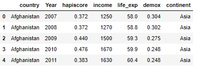

```python
from IPython.display import Image
Image("dataframe_aspect.jpg")
```

```python
#Melt dataframes
#Extract years from income dataframe to reuse it as variable name in melt method for all dataframes
years=df_income.iloc[:,1:].columns
df_hp2 = pd.melt(df_hp,id_vars=['country'],value_vars = years,var_name='Year',value_name='hapiscore')
df_income2 = pd.melt(df_income,id_vars=['country'],value_vars = years,var_name='Year',value_name='income')
df_life_exp2 = pd.melt(df_life_exp,id_vars=['country'],value_vars = years,var_name='Year',value_name='life_exp')
df_demox2 = pd.melt(df_demox,id_vars=['country'],value_vars = years,var_name='Year',value_name='demox')
df_hdi2= pd.melt(df_hdi,id_vars=['country'],value_vars = years,var_name='Year',value_name='hdi')
#print out exemple of melted dataframe
df_hp2.head()
```

|  | country | Year | hapiscore |
| --- | --- | --- | --- |
| 0 | Afghanistan | 2007 | 0.372 |
| 1 | Albania | 2007 | 0.463 |
| 2 | Algeria | 2007 | 0.546 |
| 3 | Argentina | 2007 | 0.607 |
| 4 | Armenia | 2007 | 0.488 |

```python
#df_continent.drop(columns=['year','lifeExp','pop','gdpPercap'], inplace = True, axis = 1)
df_continent.head()
```

|  | country | continent |
| --- | --- | --- |
| 0 | Afghanistan | Asia |
| 1 | Afghanistan | Asia |
| 2 | Afghanistan | Asia |
| 3 | Afghanistan | Asia |
| 4 | Afghanistan | Asia |

```python
#Drop duplicate rows from continent dataframe
df_continent.drop_duplicates(inplace=True)
df_continent.head()
```

|  | country | continent |
| --- | --- | --- |
| 0 | Afghanistan | Asia |
| 12 | Albania | Europe |
| 24 | Algeria | Africa |
| 36 | Angola | Africa |
| 48 | Argentina | Americas |

To merge all dataframes in one step, I looked for a solution in stackoverflow, I found a solution in this link: https://stackoverflow.com/questions/44327999/python-pandas-merge-multiple-dataframes

```python
#Mergin all dataframes at once
data_frames = [ df_hdi2,df_income2, df_life_exp2, df_demox2,df_hp2]
merged_df=reduce(lambda  left,right: pd.merge(left,right,on=['country','Year']), data_frames)

merged_df.head()
```

|  | country | Year | hdi | income | life_exp | demox | hapiscore |
| --- | --- | --- | --- | --- | --- | --- | --- |
| 0 | Afghanistan | 2007 | 0.431 | 1250 | 58.0 | 0.304 | 0.372 |
| 1 | Albania | 2007 | 0.718 | 8450 | 76.9 | 0.591 | 0.463 |
| 2 | Algeria | 2007 | 0.708 | 12600 | 75.7 | 0.325 | 0.546 |
| 3 | Argentina | 2007 | 0.806 | 18000 | 75.1 | 0.663 | 0.607 |
| 4 | Armenia | 2007 | 0.724 | 7010 | 73.9 | 0.412 | 0.488 |

```python
# Merge again with continent dataframe
merged_df2=pd.merge(merged_df, df_continent, left_on='country', right_on='country')
merged_df2.head()
```

|  | country | Year | hdi | income | life_exp | demox | hapiscore | continent |
| --- | --- | --- | --- | --- | --- | --- | --- | --- |
| 0 | Afghanistan | 2007 | 0.431 | 1250 | 58.0 | 0.304 | 0.372 | Asia |
| 1 | Afghanistan | 2008 | 0.436 | 1270 | 58.8 | 0.302 | 0.372 | Asia |
| 2 | Afghanistan | 2009 | 0.447 | 1500 | 59.3 | 0.275 | 0.440 | Asia |
| 3 | Afghanistan | 2010 | 0.464 | 1670 | 59.9 | 0.248 | 0.476 | Asia |
| 4 | Afghanistan | 2011 | 0.465 | 1630 | 60.4 | 0.248 | 0.383 | Asia |

```python
#last check
merged_df2.info()
```

```
<class 'pandas.core.frame.DataFrame'>
Int64Index: 1356 entries, 0 to 1355
Data columns (total 8 columns):
country      1356 non-null object
Year         1356 non-null object
hdi          1356 non-null float64
income       1356 non-null int64
life_exp     1356 non-null float64
demox        1356 non-null float64
hapiscore    1356 non-null float64
continent    1356 non-null object
dtypes: float64(4), int64(1), object(3)
memory usage: 95.3+ KB
```

### Convert year colmun to datetime

```python
#convert year column to datetime
merged_df2['Year']=pd.to_datetime(merged_df2['Year'])
merged_df2.info()
```

```
<class 'pandas.core.frame.DataFrame'>
Int64Index: 1356 entries, 0 to 1355
Data columns (total 8 columns):
country      1356 non-null object
Year         1356 non-null datetime64[ns]
hdi          1356 non-null float64
income       1356 non-null int64
life_exp     1356 non-null float64
demox        1356 non-null float64
hapiscore    1356 non-null float64
continent    1356 non-null object
dtypes: datetime64[ns](1), float64(4), int64(1), object(2)
memory usage: 95.3+ KB
```

```python
#change a year column name to lowercase
merged_df2.rename(columns={'Year': 'year'},inplace=True)
merged_df2.head()
```

|  | country | year | hdi | income | life_exp | demox | hapiscore | continent |
| --- | --- | --- | --- | --- | --- | --- | --- | --- |
| 0 | Afghanistan | 2007-01-01 | 0.431 | 1250 | 58.0 | 0.304 | 0.372 | Asia |
| 1 | Afghanistan | 2008-01-01 | 0.436 | 1270 | 58.8 | 0.302 | 0.372 | Asia |
| 2 | Afghanistan | 2009-01-01 | 0.447 | 1500 | 59.3 | 0.275 | 0.440 | Asia |
| 3 | Afghanistan | 2010-01-01 | 0.464 | 1670 | 59.9 | 0.248 | 0.476 | Asia |
| 4 | Afghanistan | 2011-01-01 | 0.465 | 1630 | 60.4 | 0.248 | 0.383 | Asia |

```python
# print statistical summary from numeric columns to find if any weird value
merged_df2.describe()
```

|  | hdi | income | life_exp | demox | hapiscore |
| --- | --- | --- | --- | --- | --- |
| count | 1356.000000 | 1356.000000 | 1356.000000 | 1356.000000 | 1356.000000 |
| mean | 0.697445 | 17758.276549 | 72.316445 | 0.588871 | 0.544212 |
| std | 0.166130 | 17622.949443 | 8.382923 | 0.208376 | 0.119719 |
| min | 0.295000 | 623.000000 | 32.500000 | 0.143000 | 0.266000 |
| 25% | 0.547750 | 3530.000000 | 65.300000 | 0.407000 | 0.451000 |
| 50% | 0.726000 | 12000.000000 | 75.000000 | 0.603500 | 0.527000 |
| 75% | 0.836000 | 27375.000000 | 79.100000 | 0.762250 | 0.637000 |
| max | 0.954000 | 96800.000000 | 85.000000 | 0.993000 | 0.797000 |

statistical summary shows that all min and max values sems logic.

```python
#Save the last version of dataframe
merged_df2.to_csv('new_df.csv', index=False)
```

## Exploratory Data Analysis

```python
# read the dataframe last version
df=pd.read_csv('new_df.csv')
```

List of functions that i will use to answer the questions:

- influenance_plot: this function must find the median of the variable in question, then it will split the data in two groups higher and lower than the median, finally it will represent the hapiscore means of each group in the same bar chart to be able to see the difference
- influence_plot_by_continent: This function will do the same work as the previous one but for each continent

```python
#(hapiscore generaly is the first_var)
def influence_plot(mydf,first_var,second_var):


        first_var_name=mydf.columns[first_var] #get the first variable name
        second_var_name=mydf.columns[second_var] # get the second variable name


        second_var_med=mydf.iloc[:,second_var].median() #Calculate the second variable median
        low_query='{}<{}'.format(second_var_name,second_var_med) # define a query statement for low then median dataframe
        hight_query='{}>{}'.format(second_var_name,second_var_med)# define a query statement for hight then median dataframe

        low_df=mydf.query(low_query) # execute low_query and assign the result to low_df
        hight_df=mydf.query(hight_query) # execute hight_query and assign the result to hight_df



        location=[1,2] #list of bars locations
        fig = plt.figure()
        fig.set_size_inches(10,10) #set a bar plot size
        bar_width = 0.35 #set a bars width
        opacity = 0.4 #set a plot opacity
        heights = [low_df[first_var_name].mean(),hight_df[first_var_name].mean()] #Assign the bar plot values
        labels = ['Low_{}'.format(second_var_name), 'High_{}'.format(second_var_name)] #assign the bars labels
        plt.bar( location, heights, tick_label=labels) # set a bar plot parameters
        plt.title('{} by {} level'.format(first_var_name,second_var_name)) #set the plot title
        plt.xlabel('{} level'.format(second_var_name)) #set the plot x label
        plt.ylabel('{}'.format(first_var_name)) # set the plot y label
        plt.show()
```

```python
#(hapiscore generaly is the first_var)
def influence_plot_by_continent(mydf,first_var,second_var):
    #set a continent names in a list
    continent_list=mydf.continent.unique().tolist() #extract the continent names existing in the dataframe
    first_var_name=mydf.columns[first_var] #extract the first variable name
    second_var_name=mydf.columns[second_var] # extract the second variable name
    low_val=[] #this list will contain values  greater than the second variable median from each continent
    hight_val=[] #this list will contain values  less than the second variable median from each continent
    n_continent=len(continent_list) #number of continent in the list



    #loop to get the mean () of values less and more the median
    for i in range(len(continent_list)):
            current_continent=continent_list[i] #get the continent name

            df_continent=mydf.query('continent==@current_continent') # get a dataframe of selected continent
            second_var_med=df_continent.iloc[:,second_var].median() # calculate the median for the specific variable
            low_query='{}<{}'.format(second_var_name,second_var_med) # define a query statement for low then median dataframe
            hight_query='{}>{}'.format(second_var_name,second_var_med) # define a query statement for hight then median dataframe

            low_df=df_continent.query(low_query) # execute low_query and assign the result to low_df
            hight_df=df_continent.query(hight_query) # execute hight_query and assign the result to hight_df

            low_val.append(float(low_df[first_var_name].mean())) #add the mean of the first variable column to low_val list
            hight_val.append(float(hight_df[first_var_name].mean()))#add the mean of the second variable column to hight list

    #plot the low_val with blue color

    fig = plt.figure()
    fig.set_size_inches(10,10) #set a bar plot size
    index = np.arange(0, n_continent * 2, 2) # bar location index
    bar_width = 0.35 #set a bars width
    opacity = 0.4 #set a plot opacity

    #plot the low_val side by side with blue color
    low_bar = plt.bar(index, low_val, bar_width,
                 alpha=opacity,
                 color='b',
                 label='Low_{}'.format(second_var_name))

    #plot the hight_val side by side with green color
    hight_bar= plt.bar(index + bar_width, hight_val, bar_width,
                 alpha=opacity,
                 color='g',
                 label='hight_{}'.format(second_var_name))



    plt.ylabel(first_var_name) #set the plot bar y label
    plt.title('{} by {} level'.format(first_var_name,second_var_name)) #set the plot bar title
    plt.xticks(index + bar_width, continent_list, rotation='vertical') #Set the continent names as x labels in the vertical rotation
    plt.legend(loc='best') # set the legend location in the best place
    plt.show()
```

Some parts of influence_plot_by_continent function are inspired form this link: https://stackoverflow.com/questions/35102221/matplotlib-set-bar-starting-point-value

### Research quesion 1: Are money makes happiness ? (influence of income on hapiscore)

In the next analysis we will try to find out if the income has an influence on the worldwide hapiness score and for each continent In order to do that we have to split the data to low income and high income.

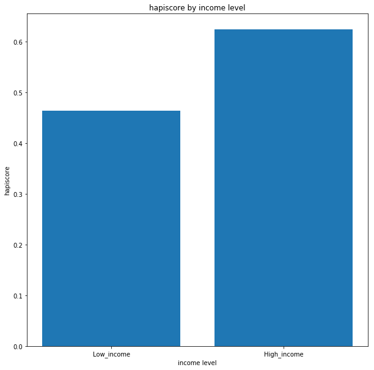

```python
#Drow the influence of income to the hapiscore
influence_plot(df,6,3)
```

The plot show that the income has globaly a positif influence on the worldwide hapiness score

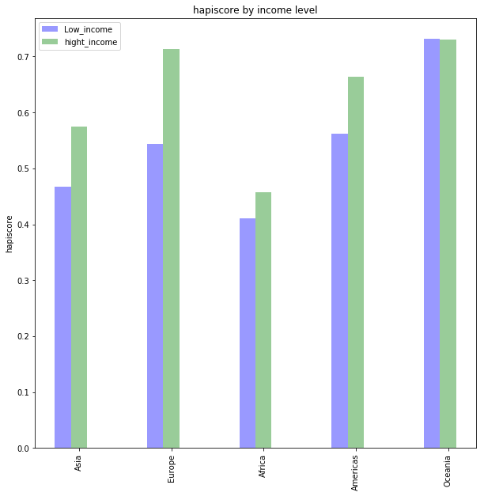

```python
#Plot the income influence on the continents hapiness score
influence_plot_by_continent(df,6,3)
```

The plot show that for every continent the income has an influence on the hapiness score except the 'Oceania'.  
The biggest income influence to hapiscore is in Europe.

### Research question 2: Are the democratic systems make their people happier in hight income countries ?

To answer this question we must first extract the hight income countries from the global dataframe then we must apply the two functions to visualize the influence of democracy index

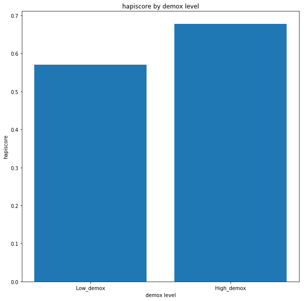

```python
income_median=df.income.median() #calculate the income median
df_hight_income=df.query('income>@income_median') # define a data frame withe hight income level
influence_plot(df_hight_income,6,5) # plot the influence of demox in hight income countrys
```

We can see from the bar plot that on the hight income countries the democracy index has a positive effect on the hapiscore

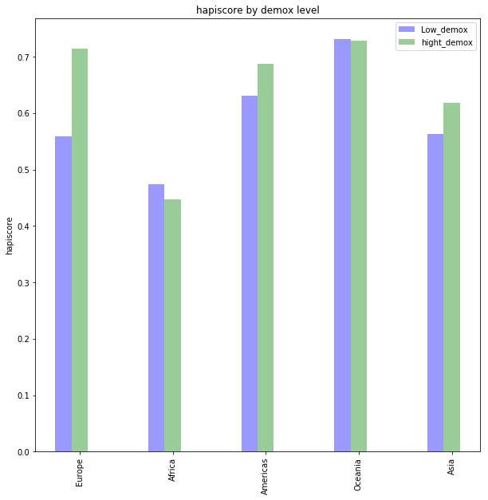

```python
influence_plot_by_continent(df_hight_income,6,5)
```

We find that Africa is the exception with a negative effect of the democracy index on the hapiscore for the countries with the higher income

### Research question 3: In low income countries do governments' efforts in human development make their people happier?

To answer this question we must first extract the low income countries from the global dataframe then we must apply the two functions to visualize the influence of human developement index on the hapiscore.

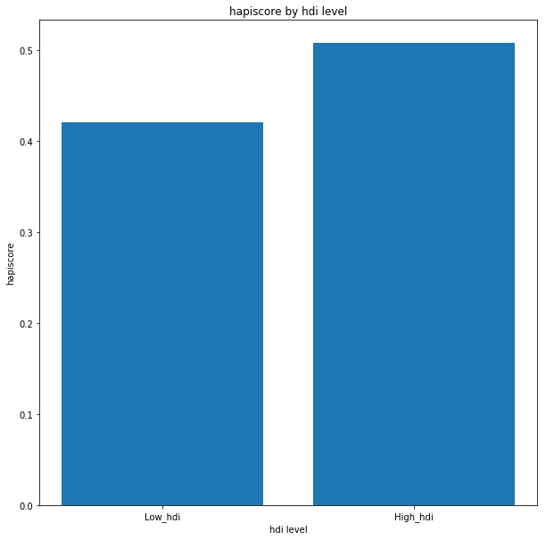

```python
income_median=df.income.median() #calculate the income median
df_low_income=df.query('income<@income_median') # define a data frame withe low income level
influence_plot(df_low_income,6,2) # plot the influence of hdi in low income countrys
```

Generaly for low-income countries the human development index has a positive influence on the hapiscore.

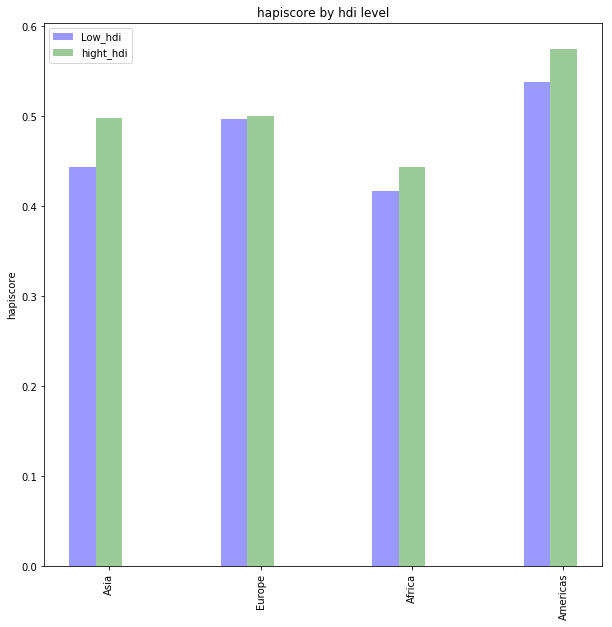

```python
influence_plot_by_continent(df_low_income,6,2)
```

In most of the continent the human development index has a positive influence on the hapiscore of low income countries, otherwise we see a weak influence on the European continent

### Research question 4: what is the caractiques of the happiest countries?

```python
#what is the caractiques of the happiest countries
df_hight_hp=df.query('hapiscore>@df.hapiscore.mean()')
df_hight_hp.describe()
```

|  | hdi | income | life_exp | demox | hapiscore |
| --- | --- | --- | --- | --- | --- |
| count | 623.000000 | 623.000000 | 623.000000 | 623.000000 | 623.000000 |
| mean | 0.823552 | 30435.874799 | 78.458427 | 0.720717 | 0.654537 |
| std | 0.095840 | 18109.734645 | 3.949377 | 0.177213 | 0.066905 |
| min | 0.502000 | 2150.000000 | 55.800000 | 0.171000 | 0.545000 |
| 25% | 0.755500 | 14950.000000 | 76.100000 | 0.637000 | 0.595500 |
| 50% | 0.846000 | 29100.000000 | 79.300000 | 0.753000 | 0.648000 |
| 75% | 0.905000 | 42950.000000 | 81.400000 | 0.838000 | 0.717000 |
| max | 0.954000 | 96800.000000 | 85.000000 | 0.993000 | 0.797000 |

the most happiest countries on average has:

- 30436 USD as yearly income
- 0.82 as Human Development Index
- 78,46 years as life expectancy
- 0.72 as democracy index

### Research question 5: what are the most important variable in predicting the hapiness score ?

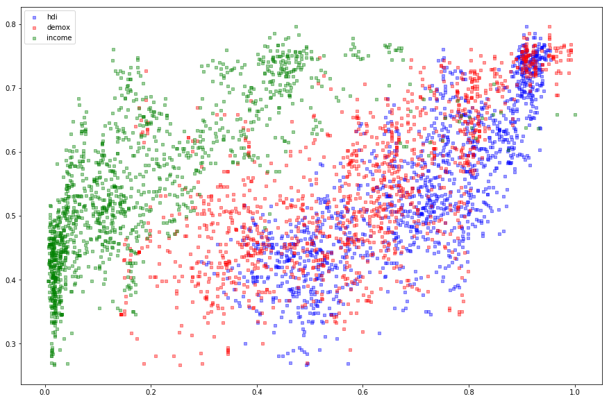

```python
#Draw all variable scatter plot in the same graphic

y = df.hapiscore
x1= df.hdi
x2= df.demox
x3= df.income/df.income.max() # changing the income scale so we can plot it in the same graphic

fig = plt.figure()
fig.set_size_inches(15,10)
ax1 = fig.add_subplot(111)

ax1.scatter(x1, y, s=10, c='b', marker="s", label='hdi', alpha=0.4)
ax1.scatter(x2,y, s=10, c='r', marker="s", label='demox', alpha=0.4)
ax1.scatter(x3,y, s=10,c='g', marker="s", label='income', alpha=0.4)
plt.legend(loc='best');
plt.show()
```

This graphic was inspired from this link: https://stackoverflow.com/questions/4270301/matplotlib-multiple-datasets-on-the-same-scatter-plot

In the worldwide scatter plot we can see that the human development index a has the strongest correlation comparing to other variables with the lowest proportion of outliers, to confirm this observation we will draw the same graph for the European continent.

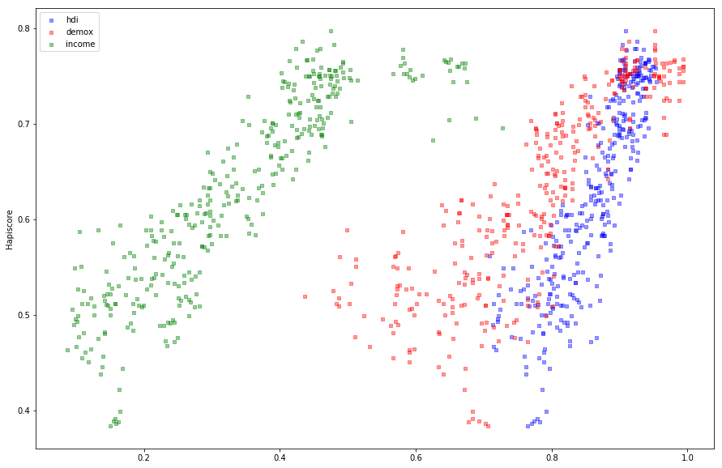

```python
df_continent=df.query('continent=="Europe"')
y = df_continent.hapiscore
x1= df_continent.hdi
x2= df_continent.demox
x3= df_continent.income/df.income.max() # changing the income scale so we can plot it in the same graphic
x4= df_continent.life_exp/df.life_exp.max()

fig = plt.figure()
fig.set_size_inches(15,10)
ax1 = fig.add_subplot(111)

ax1.scatter(x1, y, s=10, c='b', marker="s", label='hdi', alpha=0.4)
ax1.scatter(x2,y, s=10, c='r', marker="s", label='demox', alpha=0.4)
ax1.scatter(x3,y, s=10,c='g', marker="s", label='income', alpha=0.4)
#ax1.scatter(x4,y, s=10,c='y', marker="s", label='income', alpha=0.4)
plt.ylabel('Hapiscore')
plt.legend(loc='best');
plt.show()
#df.plot(y='hapiscore', x='hdi',kind='scatter');
```

For european countries it sems that the most important variable on predicting the hapiness score is the Human Development Index because it represents the strongest correlation with the lowest proportion of outliers

### Research question 6: What is the evolution over time of the hapiscore on the worldwide scale and for each continent ?

```
(0.5, 0.6)
```

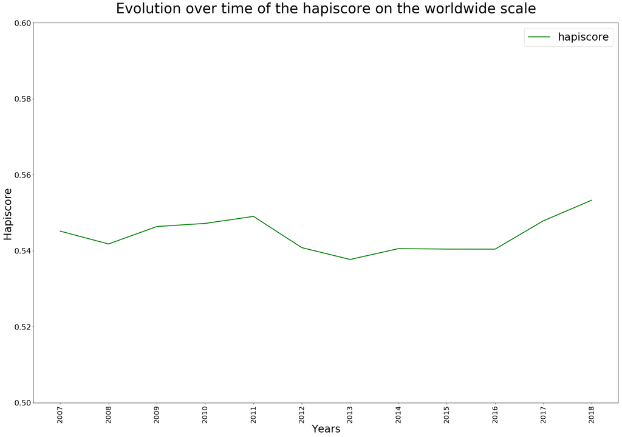

```python
df_evolution=df.groupby('year', as_index=False).mean()
years_list=pd.DatetimeIndex(df_evolution.year).year.tolist()
#sns.set(font_scale=1.4)
df_evolution.plot.line(x='year', y='hapiscore',visible=True,figsize=(30,20),linewidth=2.5, color='g')
x_axis = years_list
plt.xticks( range(len(years_list)), x_axis, fontsize=20, rotation = 90 )
plt.yticks(fontsize=22)
plt.xlabel("Years", fontsize=30)
plt.ylabel("Hapiscore", fontsize=30)
plt.title("Evolution over time of the hapiscore on the worldwide scale", y=1.02, fontsize=40);
plt.legend(loc='best',fontsize=30)
#set the y axe limits
axes = plt.gca()
axes.set_ylim([0.5,0.6])
```

From the worldwide hapiscore evolution, we observe that:

- a drop in the hapiscore from the year 2011 to 2013
- an upward trend since the year 2016

but since the variation is globally between 0.53 and 0.56 we can consider that the evolution of the hapiscore is generally stable over time

```python
#Extract dataframe containing every years mean of hapiscore for each continent
df_evolution_africa=df.query('continent=="Africa"').groupby('year', as_index=False).mean()
df_evolution_asia=df.query('continent=="Asia"').groupby('year', as_index=False).mean()
df_evolution_europe=df.query('continent=="Europe"').groupby('year', as_index=False).mean()
df_evolution_oceania=df.query('continent=="Oceania"').groupby('year', as_index=False).mean()
df_evolution_americas=df.query('continent=="Americas"').groupby('year', as_index=False).mean()

# drop unnecessary columns
df_evolution_africa.drop(df_evolution_africa.loc[:,'hdi':'demox'], inplace = True, axis = 1)
df_evolution_asia.drop(df_evolution_asia.loc[:,'hdi':'demox'], inplace = True, axis = 1)
df_evolution_europe.drop(df_evolution_europe.loc[:,'hdi':'demox'], inplace = True, axis = 1)
df_evolution_oceania.drop(df_evolution_oceania.loc[:,'hdi':'demox'], inplace = True, axis = 1)
df_evolution_americas.drop(df_evolution_americas.loc[:,'hdi':'demox'], inplace = True, axis = 1)

#Rename hapiscore column with the continent name
df_evolution_africa.rename(columns={'hapiscore': 'Africa'}, inplace= True)
df_evolution_asia.rename(columns={'hapiscore': 'Asia'}, inplace= True)
df_evolution_europe.rename(columns={'hapiscore': 'Europe'}, inplace= True)
df_evolution_oceania.rename(columns={'hapiscore': 'Oceania'}, inplace= True)
df_evolution_americas.rename(columns={'hapiscore': 'Americas'}, inplace= True)

#merge all dataframes in merged_continent_df
data_frames = [ df_evolution_africa,df_evolution_asia, df_evolution_europe, df_evolution_oceania,df_evolution_americas]
merged_continent_df=reduce(lambda  left,right: pd.merge(left,right,on=['year']), data_frames)
#Add column with year format
merged_continent_df['year_format']=pd.DatetimeIndex(merged_continent_df.year).year
merged_continent_df.head()
```

|  | year | Africa | Asia | Europe | Oceania | Americas | year_format |
| --- | --- | --- | --- | --- | --- | --- | --- |
| 0 | 2007-01-01 | 0.437912 | 0.533769 | 0.632433 | 0.7445 | 0.589190 | 2007 |
| 1 | 2008-01-01 | 0.436353 | 0.520192 | 0.633150 | 0.7315 | 0.590571 | 2008 |
| 2 | 2009-01-01 | 0.434735 | 0.523615 | 0.619175 | 0.7325 | 0.633524 | 2009 |
| 3 | 2010-01-01 | 0.430824 | 0.531038 | 0.622872 | 0.7335 | 0.629714 | 2010 |
| 4 | 2011-01-01 | 0.447375 | 0.523769 | 0.624719 | 0.7300 | 0.619524 | 2011 |

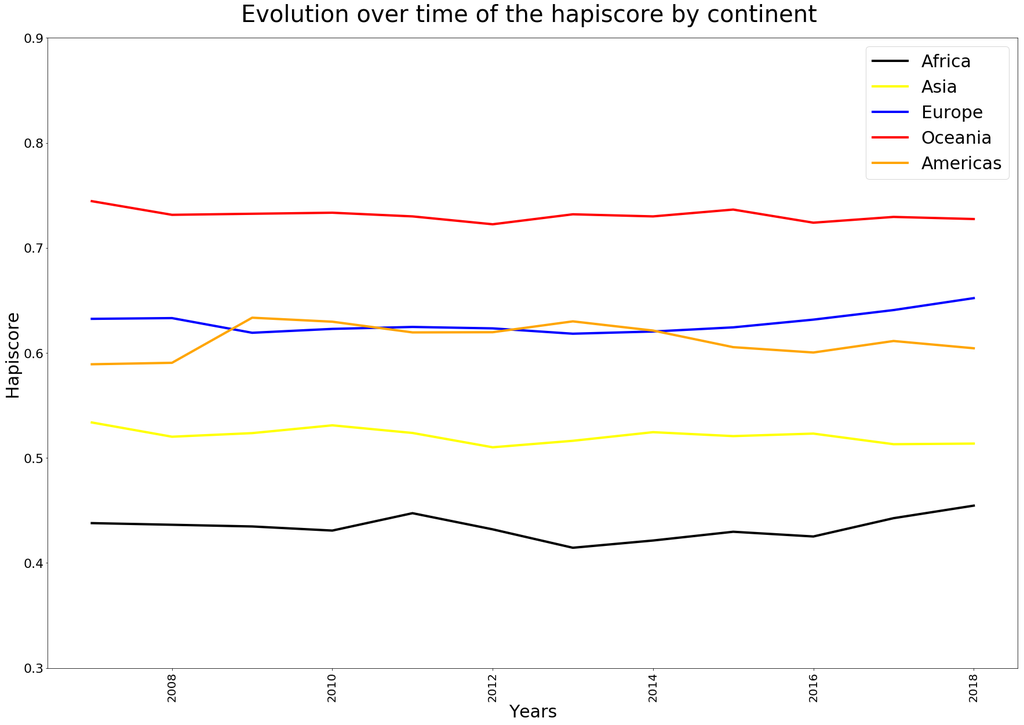

```python
# multiple line plot
plt.figure(figsize=(30,20))
plt.plot( 'year_format', 'Africa', data=merged_continent_df, color='black', linewidth=4)
plt.plot( 'year_format', 'Asia', data=merged_continent_df, color='yellow', linewidth=4)
plt.plot( 'year_format', 'Europe', data=merged_continent_df, color='blue', linewidth=4)
plt.plot( 'year_format', 'Oceania', data=merged_continent_df, color='red', linewidth=4)
plt.plot( 'year_format', 'Americas', data=merged_continent_df, color='orange', linewidth=4)
plt.xticks(  fontsize=20, rotation = 90 )
plt.yticks(fontsize=22)
plt.xlabel("Years", fontsize=30)
plt.ylabel("Hapiscore", fontsize=30)
plt.title("Evolution over time of the hapiscore by continent ", y=1.02, fontsize=40);
plt.legend(loc='best',fontsize=30)
axes = plt.gca()
axes.set_ylim([0.3,0.9])
plt.legend(loc='best',fontsize=30);
```

Note: This multiple line plot are inspired from this link:  
https://python-graph-gallery.com/122-multiple-lines-chart/

### Research question 7: Are people in happiest countrys live's longer ? (influence of hapiscore on life expectancy)

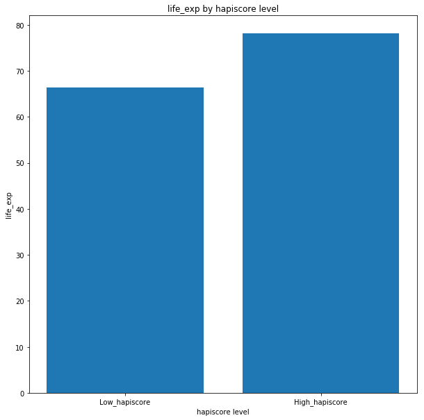

```python
#using the influence function to plot the mean of life expectancy in hight and low hapiscore average
influence_plot(df,4,6)
```

the difference in life expectancy average between hight and the low hapiscore is significant, people in happiest countries sems live much longer

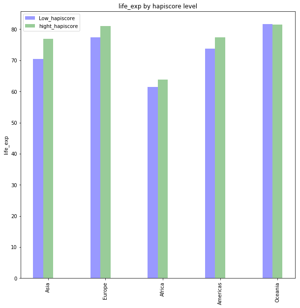

```python
# using the influence_plot_by_continent function to plot the mean of life expectancy in hight and low hapiscore average for each continent
influence_plot_by_continent(df,4,6)
```

For all continent the difference between hight and low hapiscore in life expectancy average is significant, except Oceania, the most important influence of hapiscore in life expectancy is observed in Asia, the lowest is in Africa.

## Limitation

The limitation of this project are:

- Missing data: the approach adopted to fill in the missing data can impact the final result especially when you want to analyze trends certain values are estimated.
- Droped countries: I droped 23 countries which could impact the analysis result especially in the analysis by continent.
- Population not included: for the analysis at the modial scale and even in the analysis by continent it is perhaps better to reason by the average weighted by the population, and not to consider that all the countries have the same population, China does'nt have the same weight as Montenegro there is a big difference between the population of this two countries.
- Income, Human development index and democracy index is not homogeneous between continents: this difference will impact the analysis when looking at countries between high and low level for each continent, for example to study the influence of income on the hapiscore we will have a large part classified among the high income unlike in Africa where we will have the largest part is classified as low income level.
- the variables can be interrelated: obviously citizens in democratic countries around the world generally have a high income and their governments make more efforts in terms of human development, otherwise a higher income allows a better quality of health care then a much better life expectancy

## Submitting your Project

> Before you submit your project, you need to create a .html or .pdf version of this notebook in the workspace here. To do that, run the code cell below. If it worked correctly, you should get a return code of 0, and you should see the generated .html file in the workspace directory (click on the orange Jupyter icon in the upper left).

> Alternatively, you can download this report as .html via the **File** > **Download as** submenu, and then manually upload it into the workspace directory by clicking on the orange Jupyter icon in the upper left, then using the Upload button.

> Once you've done this, you can submit your project by clicking on the "Submit Project" button in the lower right here. This will create and submit a zip file with this .ipynb doc and the .html or .pdf version you created. Congratulations!

## OPTIONAL: Question for the reviewer

If you have any question about the starter code or your own implementation, please add it in the cell below.

For example, if you want to know why a piece of code is written the way it is, or its function, or alternative ways of implementing the same functionality, or if you want to get feedback on a specific part of your code or get feedback on things you tried but did not work.

Please keep your questions succinct and clear to help the reviewer answer them satisfactorily.

```python
from subprocess import call
call(['python', '-m', 'nbconvert', 'Investigate_a_Dataset.ipynb'])
```